# Fitting Spatial Masks to Point Coordinate Data

A guide to `fit_spatial_mask()`: methods, parameters, and tuning

Raredon Laboratory · Yale School of Medicine

2026-04-03

# Overview

In spatial transcriptomics and spatial proteomics experiments, the tissue of interest occupies some irregular region of a slide. Before computing any spatially-resolved quantity (cell-type composition, signaling gradients, niche structure), you need a reliable **spatial mask**: a polygon or multi-polygon that faithfully represents the shape of the tissue, including internal voids (vessel lumens, necrotic cores, tissue tears) and disconnected fragments.

`fit_spatial_mask()` takes a set of XY point coordinates — typically cell centroids or transcript locations — and fits a mask polygon to them. It supports four methods of increasing complexity:

| Method | Topology | Speed | Best for |
| --- | --- | --- | --- |
| `"convex"` | No holes, no islands | Instant | Quick sanity checks |
| `"concave"` | No holes, no islands | Fast | Simple non-convex shapes |
| `"kde"` | Holes and islands | Moderate | Dense, smooth datasets |
| `"raster"` | Holes and islands | Fast at scale | Most use cases; recommended default |

# Setup

Place `fit_spatial_mask.R` in your working directory, then source it. The packages below are required.

```r
library(sf)
library(ggplot2)
library(patchwork)
source("fit_spatial_mask.R")

set.seed(42)
```

# Shared plotting helper

Throughout this vignette we use a single `plot_mask()` helper. The key implementation note is that it uses `geom_sf()` rather than `geom_polygon()`. This is essential: `geom_polygon()` draws a line between the last vertex of the exterior ring and the first vertex of each interior (hole) ring, producing diagonal artefacts. `geom_sf()` delegates rendering to the sf/GEOS layer which handles holes correctly.

```r
plot_mask <- function(mask, coords, title = "", subtitle = "",
                      fill = "#4c9be8", border = "#1a5fa8",
                      pt_col = "#c0392b", pt_size = 1.2, pt_alpha = 0.55) {
  mask_sf <- sf::st_sf(geometry = mask)
  ggplot() +
    geom_sf(data = mask_sf, fill = fill, alpha = 0.2,
            color = border, linewidth = 0.55) +
    geom_point(data = coords, aes(x = x, y = y),
               color = pt_col, size = pt_size, alpha = pt_alpha) +
    coord_sf(datum = NA) +   # suppress geographic graticule
    labs(title = title, subtitle = subtitle, x = "X", y = "Y") +
    theme_minimal(base_size = 9.5) +
    theme(plot.title    = element_text(face = "bold", size = 9.5),
          plot.subtitle = element_text(size = 8, color = "grey40"),
          panel.grid    = element_line(color = "grey93"))
}
```

# Function reference: `fit_spatial_mask()`

```r
fit_spatial_mask(
  coords,

  # Method selection
  method            = "raster",   # "convex" | "concave" | "kde" | "raster"

  # Concave hull
  concavity         = 2,          # lower = tighter; higher = approaches convex
  length_threshold  = 0,

  # KDE
  kde_bandwidth     = NULL,       # NULL = auto (bandwidth.nrd)
  kde_threshold     = 0.05,       # quantile of density to threshold at
  kde_resolution    = 256L,

  # Raster (recommended)
  raster_resolution = 256L,       # grid cells per axis
  raster_sigma      = NULL,       # Gaussian spread in COORDINATE UNITS; NULL = 3% of domain
  raster_threshold  = 0.15,       # fraction of peak Gaussian field to threshold at
  raster_min_pts    = 1L,         # min points per cell to count as occupied

  # Post-processing
  buffer_dist       = 0,          # expand mask outward by this distance
  smooth_mask       = FALSE,      # simplify boundary (st_simplify)
  smooth_tolerance  = NULL,       # NULL = 1% of bounding box diagonal

  # Misc
  n_cores           = 1L,
  crs               = NA,
  plot              = FALSE,
  verbose           = TRUE
)
```

## Return value

`fit_spatial_mask()` returns an `sfc` geometry object (the `sf` package’s geometry column class). You can:

- Pass it directly to `estimate_concentration_field()` as the `mask` argument
- Plot it with `geom_sf()`
- Compute area with `sf::st_area()`
- Test point containment with `sf::st_within()`
- Convert to a data frame with `as.data.frame(sf::st_coordinates(mask))`

# Section 1 — Circular cloud: sanity check

The simplest possible test: a Gaussian cloud with no special topology. All three non-trivial methods should return similar results here. This section establishes that the function runs and that the three main methods agree on simple inputs.

```r
n              <- 400
coords_circle  <- data.frame(x = rnorm(n, 0, 1),
                              y = rnorm(n, 0, 1))
```

```r
m1a <- fit_spatial_mask(coords_circle, method = "convex",  verbose = FALSE)
m1b <- fit_spatial_mask(coords_circle, method = "concave", concavity = 2,
                         verbose = FALSE)
m1c <- fit_spatial_mask(coords_circle, method = "kde",
                         kde_threshold = 0.02, buffer_dist = 0.1,
                         verbose = FALSE)
```

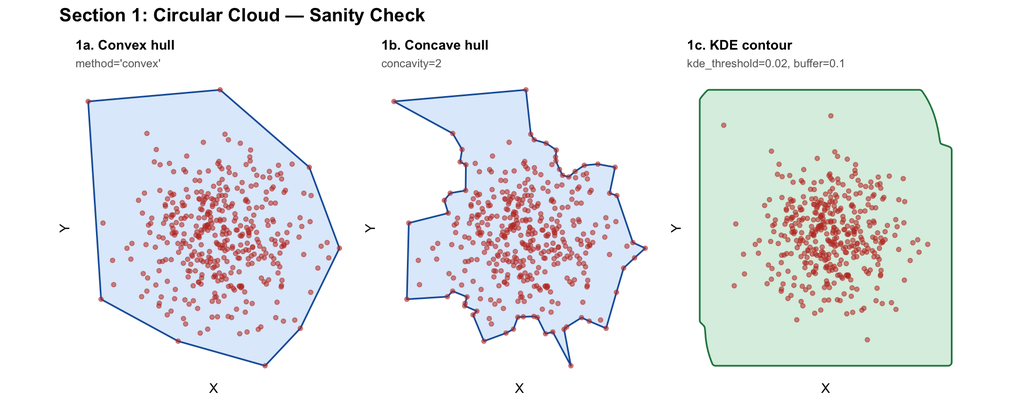

```r
plot_mask(m1a, coords_circle, title = "1a. Convex hull",
          subtitle = "method='convex'") +
plot_mask(m1b, coords_circle, title = "1b. Concave hull",
          subtitle = "concavity=2") +
plot_mask(m1c, coords_circle, title = "1c. KDE contour",
          subtitle = "kde_threshold=0.02, buffer=0.1",
          fill = "#27ae60", border = "#1e8449") +
plot_annotation(
  title = "Section 1: Circular Cloud — Sanity Check",
  theme = theme(plot.title = element_text(face = "bold", size = 13)))
```

# Section 2 — Elongated cloud: anisotropy

Elongated tissue (e.g. a muscle section, a linear airway epithelium) has very different extents along its two axes. All methods should handle this naturally; this section confirms that no method is implicitly assuming isotropy.

```r
coords_elong <- data.frame(x = rnorm(n, 0, 3),
                            y = rnorm(n, 0, 0.6))

m2a <- fit_spatial_mask(coords_elong, method = "convex",  verbose = FALSE)
m2b <- fit_spatial_mask(coords_elong, method = "concave", verbose = FALSE)
m2c <- fit_spatial_mask(coords_elong, method = "kde",
                         kde_threshold = 0.02, buffer_dist = 0.1,
                         verbose = FALSE)
```

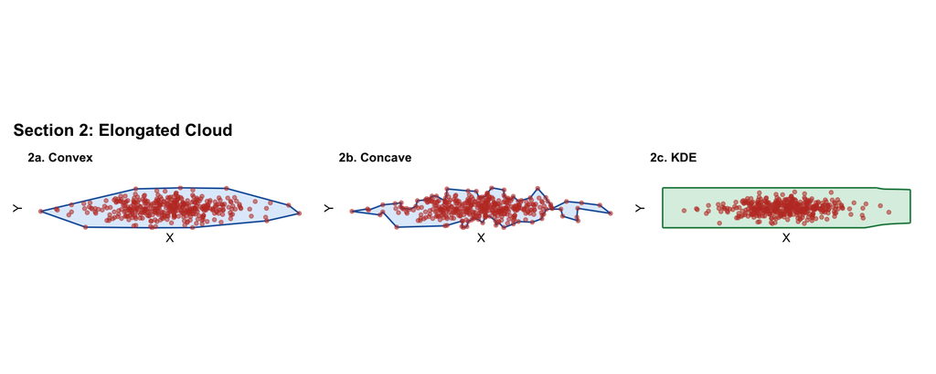

```r
plot_mask(m2a, coords_elong, title = "2a. Convex") +
plot_mask(m2b, coords_elong, title = "2b. Concave") +
plot_mask(m2c, coords_elong, title = "2c. KDE",
          fill = "#27ae60", border = "#1e8449") +
plot_annotation(
  title = "Section 2: Elongated Cloud",
  theme = theme(plot.title = element_text(face = "bold", size = 13)))
```

**What to look for:** The mask should track the long axis of the cloud, not default to a circle. The KDE bandwidth is computed separately for x and y (`MASS::bandwidth.nrd`), so it adapts to anisotropy automatically.

# Section 3 — L-shaped cloud: the non-convex diagnostic

This is the most important basic test. The L-shape is the canonical non-convex case: the convex hull incorrectly fills the concave corner of the L, including empty space that contains no tissue. A good mask must track the actual boundary and exclude the corner.

> **Rule of thumb:** If your tissue has any re-entrant angles (C-shapes, crescents, airways, arcs), do not use `method = "convex"`. Use `method = "concave"` or `method = "raster"`.

```r
coords_L <- rbind(
  data.frame(x = runif(200, 0, 5) + rnorm(200, 0, 0.05),
             y = runif(200, 0, 1) + rnorm(200, 0, 0.05)),   # horizontal bar
  data.frame(x = runif(200, 0, 1) + rnorm(200, 0, 0.05),
             y = runif(200, 0, 5) + rnorm(200, 0, 0.05)))   # vertical bar
```

```r
m3a <- fit_spatial_mask(coords_L, method = "convex",  verbose = FALSE)
m3b <- fit_spatial_mask(coords_L, method = "concave", concavity = 1.5, verbose = FALSE)
m3c <- fit_spatial_mask(coords_L, method = "concave", concavity = 3.0, verbose = FALSE)
```

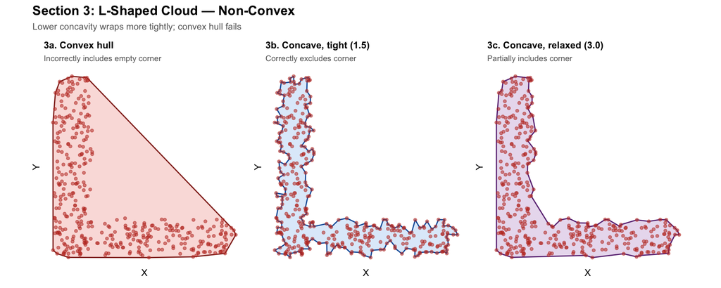

```r
plot_mask(m3a, coords_L,
          title = "3a. Convex hull",
          subtitle = "Incorrectly includes empty corner",
          fill = "#e74c3c", border = "#922b21") +
plot_mask(m3b, coords_L,
          title = "3b. Concave, tight (1.5)",
          subtitle = "Correctly excludes corner") +
plot_mask(m3c, coords_L,
          title = "3c. Concave, relaxed (3.0)",
          subtitle = "Partially includes corner",
          fill = "#8e44ad", border = "#6c3483") +
plot_annotation(
  title    = "Section 3: L-Shaped Cloud — Non-Convex",
  subtitle = "Lower concavity wraps more tightly; convex hull fails",
  theme    = theme(plot.title    = element_text(face = "bold", size = 13),
                   plot.subtitle = element_text(size = 9, color = "grey40")))
```

### The `concavity` parameter

`concavity` controls how aggressively the hull “cuts in” to follow the data boundary. It is the key tuning parameter for `method = "concave"`.

| Value | Behaviour |
| --- | --- |
| 1.0–1.5 | Very tight — tracks the data boundary closely |
| 2.0 | Default — good balance for most tissue shapes |
| 3.0–5.0 | Relaxed — approaches the convex hull |

**When to use lower values:** C-shapes, crescents, U-shapes, any tissue with a notch or bay. **When to use higher values:** Dense blobs where you want a smooth, padded boundary. If you see the mask cutting through the interior of your tissue, increase `concavity`. If it fills in empty space at concavities, decrease it.